# Artificial Surface Projections for 2050 | Norway

Magnus Merkle (SSB) and Kristine Grimsrud (SSB)

Naturregnskapsprosjekt, 4. November 2025

# Changelog

Changes since version 0:

- set up first version

# Abstract and Limitation

In this notebook we make artificial surface projections for Norway until 2050. For the time being the only data inputs are:

- Grunnkart
- Befolkningsframskrivninger fra SSB
- Municipality shapefiles

The process is set up to run in four steps. First we estimate a function explaining artificial surface proportions by municipality, using cross-sectional data variation across municipalities. Second, we plug in data projections into the function from step 1, to compute the new artificial surface proportions for 2050. Third, we make a gridded map of urbanisation suitability. Fourth, we allocate new artificial surface cells to the land cover map for 2050, using the outputs of steps 2 and 3. To summarise: Absolute growth in artificial surface by municipality is the outcome of exogenously modelled results fed into an econometrically calibrated model, while allocation of new artificial surface within each municipality follows an exogenously defined land suitability logic.

# 1. Filepaths and packages

```r
# packages
library(dplyr)
library(tidyr)
library(terra)
library(ggplot2)
library(sf)
# filepath to the wd
wfp<-file.path("C:","Users","muk",
               paste0("OneDrive - Statistisk sentralbyr","\U00E5"),
               "Projects","Naturregnskap","arealframskrivninger","analysis")
# filepath to Grunnkart
gfp<-file.path("C:","Users","muk",
               paste0("OneDrive - Statistisk sentralbyr","\U00E5"),
               "data","INCA","Norway_files","Grunnkart")
# filepath to municipalities
mfp<-file.path("C:","Users","muk",
               paste0("OneDrive - Statistisk sentralbyr","\U00E5"),
               "data","Norway")
# filepath to population data
pfp<-file.path("C:","Users","muk",
               paste0("OneDrive - Statistisk sentralbyr","\U00E5"),
               "data","SSB","Population")
```

# 2. Get data

In this section we run scripts to import data, aggregate it to the desired resolution, and match it in preparation for the subsequent analysis.

## 2.1 Land cover map

Grunnkart raster file.

```r
lcm <- terra::rast(file.path(gfp,"Grunnkart_OT.tif"))
```

## 2.2 Municipality map

Municipality shapefile.

```r
mm <- terra::vect(file.path(mfp,"Basisdata_0000_Norge_3035_Kommune_GeoJSON.geojson"))
mmd<-as.data.frame(mm)
```

## 2.3 Population tables

Population for 2024 and 2050, by municipality.

```r
pd <- read.csv(file.path(pfp,"14288_20251024-085215.csv"),sep=";")
colnames(pd)<-c("municipality","year","value")
pd <- pd %>% filter(year %in% c(2024,2050))
```

## 2.4 Artificial surface density

Now we commpute the share of artificial surface in each municipality. First we need to define what artificial surface is. Below are all categories.

```r
unique(lcm)
```

```
##                                                                            Class
## 1                                           Bebyggelse/samferdsel (uspesifisert)
## 2                                                   Sammenhengende boligområder
## 3                Sammenhengende områder for tjenesteyting, handel \nog industri
## 4                                                         Oppdelte boligområder
## 5                                                                  Infrastruktur
## 6                                  Vei- og jernbanenettverk med tilhørende mark
## 7                                                                  Havneområder
## 8                                                                     Flyplasser
## 9                                                            Annen infrastruktur
## 10                                                     Mineralutvinningsområder
## 11                                                                        Parker
## 12                                                Sports- og rekreasjonsområder
## 13                                                      Gravlunder, kirkegårder
## 14                                                  Jordbruksmark (uspesifisert)
```

[output cut: 16 more lines]

For a start we just group all of the first thirteen categories of Grunnkartet together and call those artificial surface. We ignore variation within them. Then we compute total surface for each municipality and then artificial surface.

```r
# lcm with aggregated categories
lcma<-lcm
# basically a change of code
lcma[lcma %in% c(100,111,112,121,130,131,132,133,134,135,141,142,152)]<-199
values(lcma)<-as.numeric(values(lcma))
# now we need to mask grunnkartet to our municipalities
lcma <- mask(lcma,mm)
# Then count the number of cells of each kind in each polygon (municipality)
df <- terra::extract(lcma,mm,fun=table,method="simple")
# Then count all cells that could potentially be built up (classes 200,300,400,500)
df['artif']<-df$`199`
df['available']<-df$`199`+df$`200`+df$`320`+df$`400`+df$`410`+df$`420`+df$`440`+df$`520`
df['unavailable']<-df$`600`+df$`611`+df$`623`+df$`631`+df$`720`+df$`810`+df$`910`+df$`1100`+df$`1200`+df$`9900`
# keep only what is needed
df <- df %>% select(ID,artif,available,unavailable)
# add municipality names (same order)
df['munic']<-mmd$kommunenavn
df['munid']<-mmd$kommunenummer
df['artifshare']<-df$artif/df$available
```

## 2.5 Population density

Population density is simply the amount of population divided by available land.

```r
# match pd with df
pd <-pd %>% mutate(munid = substr(municipality, 1, 4))
unique(pd$munid) %in% df$munid
# join data
df <- df %>% left_join(pd %>% filter(year==2024) %>% select(-year) %>% rename(pop = value),by="munid")
# compute population density
df['popdens']<-df$pop/(0.01*df$available)
```

# 3. Analysis Step 1

Now let’s look at our data and plot population density against artificial surface share.

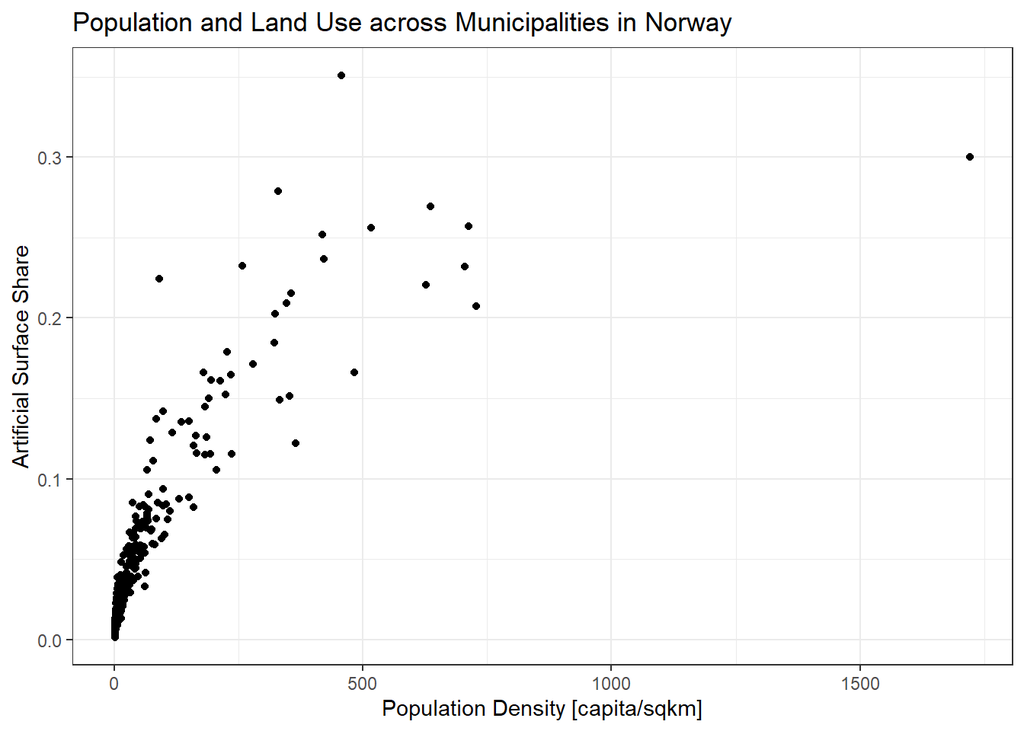

```r
# make a plot
ggplot(df,aes(x=popdens,y=artifshare)) +
  geom_point() +
  labs(title="Population and Land Use across Municipalities in Norway",
       y="Artificial Surface Share",x="Population Density [capita/sqkm]") +
  theme_bw()
```

Ok so this looks like a concave positive relationship as expected. Let’s define a function that could describe such a relationship. We want it have the following properties:

- Start in the origin
- Be concave
- Level off at 1

Here is MM’s suggested function:

$$f(x) = \frac{x}{x+a}$$

where parameter $a$ defines how quickly the function reaches 1. Now let’s use a non-linear weighted least squares estimation to get parameter $a$ based on our data. The weight we apply is the overall size of the municipality (larger size gives more weight).

```r
estresult<-nls(artifshare ~ popdens/(popdens+a),data = df,weights=available+unavailable,start=list(a=1000))
summary(estresult)
```

```
##
## Formula: artifshare ~ popdens/(popdens + a)
##
## Parameters:
##   Estimate Std. Error t value Pr(>|t|)
## a  1180.63      38.25   30.86   <2e-16 ***
## ---
## Signif. codes:  0 '***' 0.001 '**' 0.01 '*' 0.05 '.' 0.1 ' ' 1
##
## Residual standard error: 8.546 on 356 degrees of freedom
##
## Number of iterations to convergence: 6
## Achieved convergence tolerance: 1.421e-06
```

And then plot it.

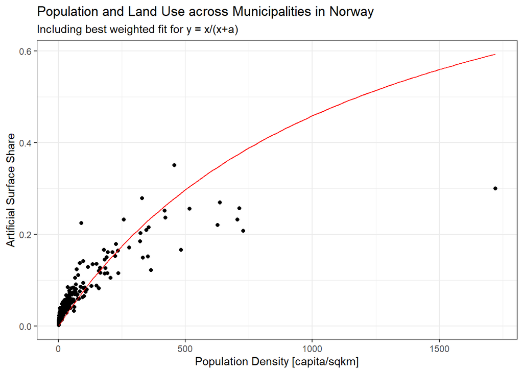

```r
# define the function for ggplot
a = coef(estresult)
ourfunction<-function(x){x/(x+a)}
# make a plot
ggplot(df,aes(x=popdens,y=artifshare)) +
  geom_point() +
  labs(title="Population and Land Use across Municipalities in Norway",
       subtitle = paste0("Including best weighted fit for y = x/(x+a)"),
       y="Artificial Surface Share",x="Population Density [capita/sqkm]") +
  geom_function(fun=ourfunction,colour="red")+
  theme_bw()
```

```r
# clean up
rm(estresult)
```

# 4. Analysis Step 2

Now we use population projections to compute the population density for 2050 in each municipality. And then we use our function to compute the new artificial surface share in 2050 for each municipality

```r
# add projection to df
df <- df %>%
  left_join(pd %>% filter(year==2050) %>% select(-c(municipality,year)) %>% rename(pop_2050 = value),by="munid")
# compute new density
df['popdens_2050']<-df$pop_2050/(0.01*df$available)
# and compute the change
df['popdens_chg']<-df$popdens_2050-df$popdens
# and also relative change in percent
df['popdens_chg_rel']<-100*df$popdens_chg/df$popdens
# then compute the change we would expect using our function
df['artifshare_chg']<-ourfunction(x=df$popdens_2050)-ourfunction(x=df$popdens)
# then compute the new artificial surface share
df['artifshare_2050']<-df$artifshare + df$artifshare_chg
# and then compute the new artificial surface extent
df['artif_2050']<-round(df$artifshare_2050*df$available,digits=0)
# and compute the absolute change
df['artif_chg'] <- df$artif_2050 - df$artif
# clean up
rm(pd)
```

Let’s make a plot showing artificial surface changes by municipality.

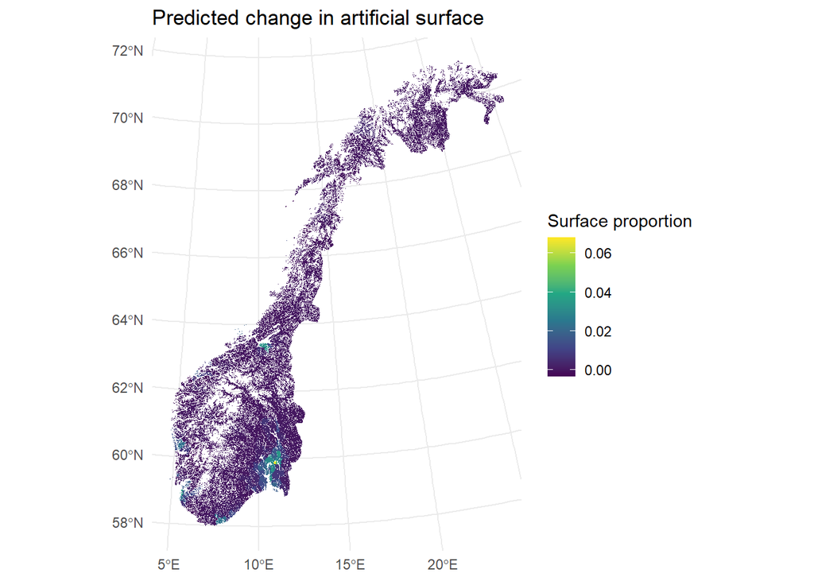

```r
# make a mask to show only available land
lcmb<-lcma
lcmb[lcmb %in% c(600,611,623,631,720,810,910,1100,1200,9900)]<-NA
lcmb[lcmb>1]<-1
mask_poly <- as.polygons(lcmb, dissolve = TRUE, na.rm = TRUE)
#  turn our data into a spatial vector object
dfd<-df %>% rename(kommunenummer = munid)
mdfd <- merge(mm,dfd,by="kommunenummer")
# mask it
mdfd <- crop(mdfd,mask_poly)
mdfd <- intersect(mdfd,mask_poly)
# nicer plots with sf objects in ggplot (ggplot doesn't read terra spatial vector objects)
mdfd_sf <- sf::st_as_sf(mdfd)
ggplot(mdfd_sf) +
  geom_sf(aes(fill = artifshare_chg),color=NA) +
  scale_fill_viridis_c() +
  theme_minimal() +
  labs(title = "Predicted change in artificial surface",
       fill = "Surface proportion")
```

```r
# clean up
rm(mdfd_sf,mdfd,df,mask_poly)
```

# 5. Analysis Step 3

Now we need to define the eligibility of each cell that is not already artificial to turn into an artificial cell. This could be a sophisticated process taking all kinds of information into account (infrastructure, flood risk, slope, land use plans, etc.). As a first draft, we implement a simple process that only takes current land use into account.

Step i) We compute the proportion of artificial cells in a radius of 5 km. Then normalise the result again to an indicator defined on [0;1]. Then multiply by 100 so we have an index of urbanisation potential based on given density of artificial surface around.

Step ii) We rank land use categories by their urbanisation potential. Note category 310 (sown pastures and fields) does not exist in the current Grunnkart version, so we do not include it here.

Here is MM’s suggested ranking:

1. 320 Natural and seminatural grasslands: 0.9
2. 520 Heathland and sub-alpine shrub: 0.7
3. 400, 410, 420, 440 alls kinds of forest: 0.5
4. 200 Annual cropland: 0.3

This is basically an eligibility reduction factor. If a cell is annual cropland, its density-based eligibility gets reduced by 70%. If it is grassland, then it only gets reduced by 10%. Note that this definition is not based on anything else than subjective deliberation, and it should be revisited.

Step iii) Next we compute the distance of each cell to its closest artificial cell. Then we normalise it to an indicator defined on [0;1] and subtract the result from 1, so that 0 is furthest away. So this is again an eligibility reduction factor, which reduces eligibility depending on how far the closest artificial cell is located.

Step iv) We define eligibility as the product of the results from i), ii), and iii).

```r
## Step i)
# a) Make a target map. 1 is artificial, 0 is everything else.
targetr <- lcma
targetr[targetr==199]<-1
targetr[targetr>1]<-0
# b) Make it coarser from 1ha to 4ha (because MM's laptop can't handle the focal function otherwise)
targetrc <- terra::aggregate(targetr,fact=2,fun=mean)
# c) Make a round moving window of 5km radius
w = terra::focalMat(targetrc,5000,type = "circle")
w[w>0]<-1 # all artificial cells get the same weight of 1
# d) run the focal function to compute the sum of artificial cells within 5km radius for each cell
r_sum <- terra::focal(targetrc,w,fun=sum,na.policy = "omit")
# e) Disaggregate again using interpolation
r_fine <- terra::disagg(r_sum,fact=2,method="bilinear")
# f) Then we need to align extents using interpolation
r_fine_a <- terra::resample(r_fine,lcma,method="bilinear")
# g) normalise and make an index, gives us the result
s1r <- 100*r_fine_a/max(values(r_fine_a),na.rm=T)
# h) clean up
rm(targetr,targetrc,w,r_sum,r_fine,r_fine_a)

## Step ii)
# a) Baseline is lcm
s2r<-lcma
# b) unavailable
s2r[s2r %in% c(600,611,623,631,720,810,910,1100,1200,9900)]<-0
# c) unavailable because already artificial
s2r[s2r %in% c(199)]<-0
# d) best
s2r[s2r == 320]<-0.9
# e) second best
s2r[s2r == 520]<-0.7
# f) third best
s2r[s2r %in% c(400,410,420,440)]<-0.5
# g) fourth best
s2r[s2r == 200]<-0.3

## Step iii)
# a) Make a target map, 1 is artificial, all else is NA
targetr <- lcma
targetr[targetr==199]<-1
targetr[targetr>1]<-NA
# b) Compute distance of each cell to the target
distm <- terra::distance(targetr)
distm<-terra::mask(distm,lcmb)
# c) Then our adjustment map
s3r <- 1-distm/max(values(distm),na.rm=T)
# d) Clean up
rm(distm,targetr)

## Step iv)
# Create our eligibilty raster as the product
elig_r <- s1r*s2r*s3r
# And clean up
rm(s1r,s2r,s3r)
gc()
```

Then let’s have a look at our resulting map of eligibility.

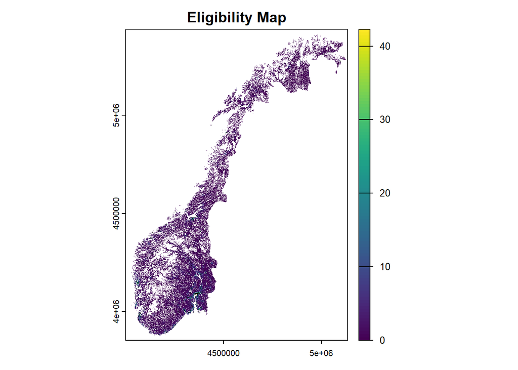

```r
# Here is our raster
plot(elig_r,main="Eligibility Map")
# Make a layer with already urban cells
urb<-lcma
urb[urb==199]<-1
urb[urb>1]<-NA
# And add that
plot(urb,col="black", add=T,legend=F)
```

Let’s zoom in on the Oslo area to see a bit more.

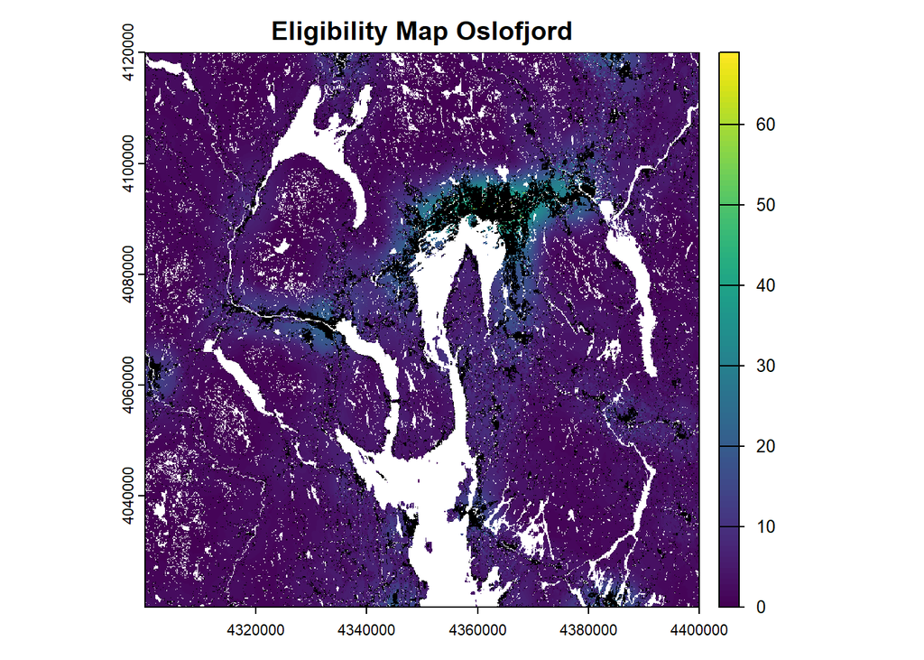

```r
oslo_ext <- ext(4300000, 4400000, 4020000, 4120000)
plot(crop(elig_r,oslo_ext),main="Eligibility Map Oslofjord")
plot(crop(urb,oslo_ext),col="black", add=T,legend=F)
```

# 6. Analysis Step 4

Now as the last step of our analysis we allocate new artificial cells to the land cover map. We do this on the basis of eligibility, defined by step 3. The number of cells to be added in each municipality comes from step 2. We implement the process as a loop across municipalities.

MM to do: Check that all eligibility values are unique, no duplicates.

```r
gc()
# first define negative artificial surface change as zero change.
dfd$artif_chg[dfd$artif_chg<0]<-0
# we need character municipality identification codes (otherwise rasterize will return levels)
mmc<-mm
mmc$kommunenummer <- as.character(mmc$kommunenummer)
# Extract eligibility values for each municipality
elig_df <- terra::extract(elig_r, mmc)
colnames(elig_df)<-c("ID","elig")
# and then i also want kommunenummer
elig_df$kommunenummer <- mmc$kommunenummer[elig_df$ID]
# now compute the thresholds in a loop across municipalities
dfd['elig_tld']<-NA
for(i in 1:nrow(dfd)){
  if(dfd$artif_chg[i]>0){
    # for debugging
    # print(dfd$municipality[i])
    # operation
    dfd$elig_tld[i]<-sort(elig_df$elig[elig_df$kommunenummer==dfd$kommunenummer[i]],decreasing = T)[dfd$artif_chg[i]]
  }
}
# now set the threholds for those municipalities where there is no urbanisation to 100
dfd$elig_tld[is.na(dfd$elig_tld)]<-100
# now merge with our municipality spatial vector
mdfd <- merge(mm,dfd,by="kommunenummer")
# then rasterize
eligtld_r<-terra::rasterize(mdfd,lcma,field="elig_tld")
# good and now the raster of new artificial cells
newart_r<-lcma
newart_r[newart_r>0]<-NA
# new cells where eligibilty is larger than the minimum threhold
newart_r[elig_r>=eligtld_r]<-1
```

Here a plot of the result. A bit difficult to see when looking at the whole country.

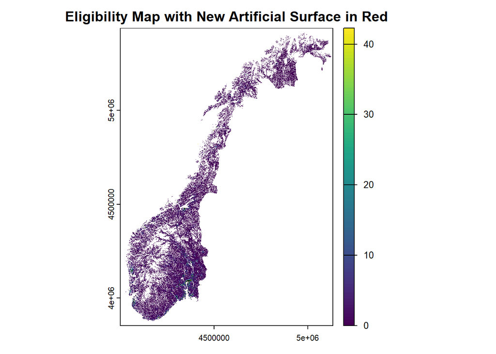

```r
# Here is our raster
plot(elig_r,main="Eligibility Map with New Artificial Surface in Red")
# And add urban layer
plot(urb,col="black", add=T,legend=F)
# and add the new ones
plot(newart_r,colour="red",add=T,legend=F)
```

Zooming into Oslo we can see a bit more.

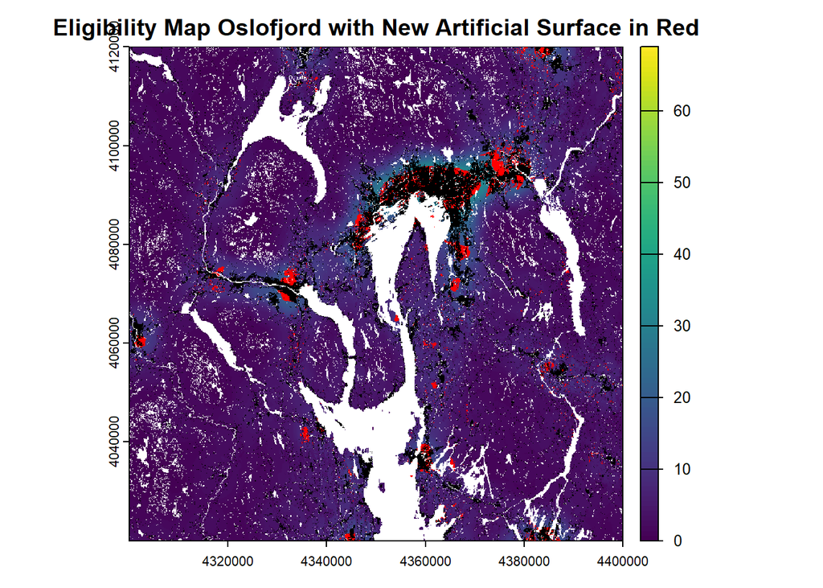

```r
plot(crop(elig_r,oslo_ext),main="Eligibility Map Oslofjord with New Artificial Surface in Red")
plot(crop(urb,oslo_ext),col="black", add=T,legend=F)
plot(crop(newart_r,oslo_ext),col="red", add=T,legend=F)
```

```r
sr<-round(100*((sum(dfd$artif_chg)-sum(values(newart_r),na.rm=T))/sum(dfd$artif_chg)),digits=1)
print(paste0("Predicted artificial surface change was allocated with ",sr," % error margin."))
```

```
## [1] "Predicted artificial surface change was allocated with -0.2 % error margin."
```

# 7. Result Plots and Tables

To be added, depending on what we want to zoom into. Cities? Specific area cases? Land cover transformation tables?

```r
writeRaster(newart_r,file.path(wfp,"results","newartif.tif"),overwrite=T)
write.csv(dfd,file.path(wfp,"results","calculationdf.csv"))
```

# 8. Ideas for Extensions

Many :-)